# Site Justification

Kate Culhane

## Fire severity

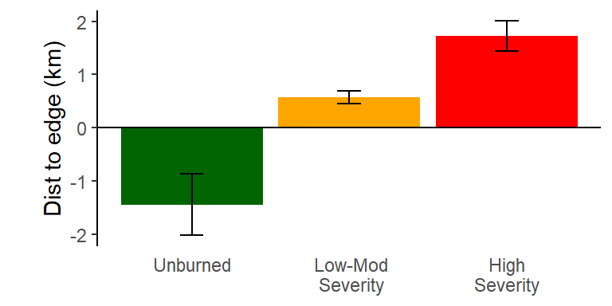

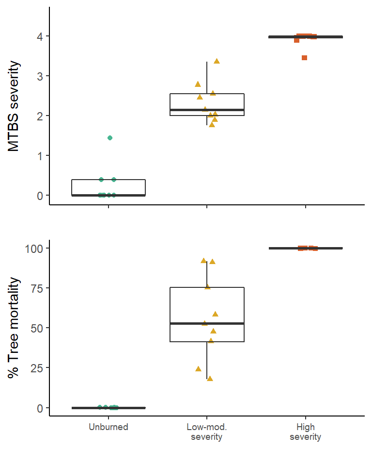

- **Figure 1D**
- Fire severity classes from Monitoring Trends in Burn Severity (MTBS)
- All differences significant for average MTBS severity and % tree mortality (Kruskal Wallis, post-hoc by Dunn’s test with Bonferroni correction, $\alpha$ = 0.05)

### PCA of the three severity metrics

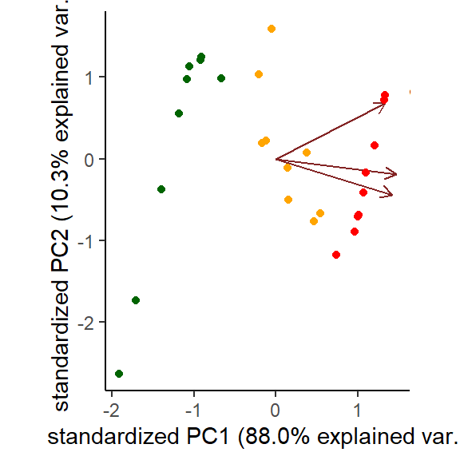

**Number lines showing the 27 sites arranged by severity metrics:**

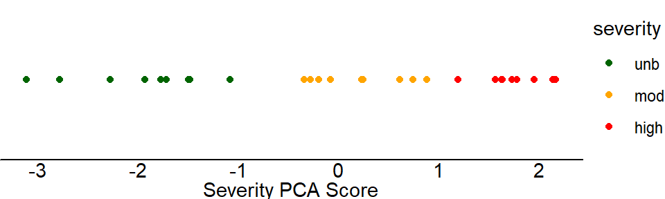

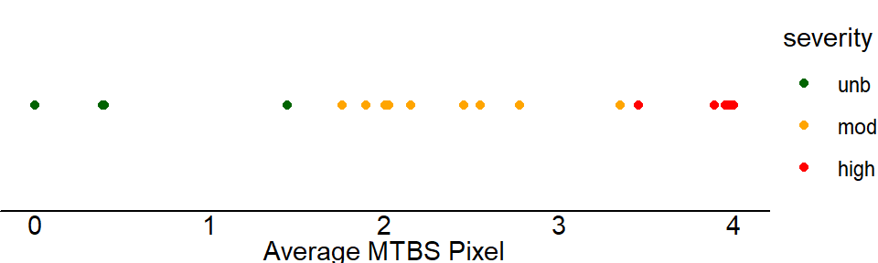

## Pre- vs. post-fire similarity

### EVC and EVT

Existing Vegetation Cover and Existing Vegetation Type (LANDFIRE spatial data)

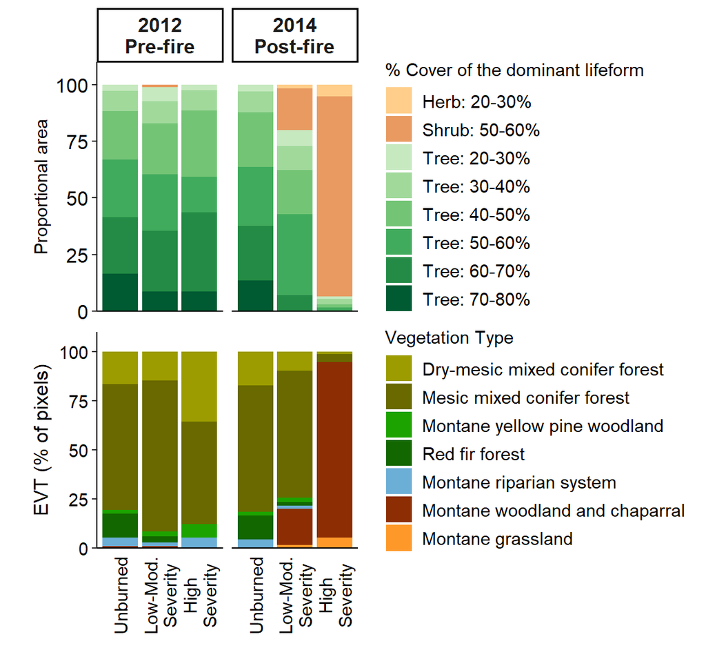

**Comparing between pre-fire vs. post-fire, for each severity category**

```
##       severity   group1  group2  n1  n2 statistic         p      p_adj    effsize magnitude
## 1     Unburned postfire prefire 562 558  149933.0  1.91e-01  5.730e-01 0.03906885     small
## 2 Low/Moderate postfire prefire 848 640  172929.0  8.91e-37  2.673e-36 0.32840067  moderate
## 3         High postfire prefire 905 632    3419.5 3.27e-298 9.810e-298 0.94145696     large
```

- Used Wilcoxon ranked sum test because the data is ordinal
- Bonferroni correction for multiple comparisons

**Comparing among the three severity categories, for both pre-fire and post-fire**

```
##   year    n  statistic df       p         method   p_adj     effsize  method magnitude
## 1 2012 1830   12.31326  2 0.00212 Kruskal-Wallis 0.00424 0.005644916 eta2[H]     small
## 2 2014 2315 1534.75264  2 0.00000 Kruskal-Wallis 0.00000 0.662955295 eta2[H]     large
```

```
##   Kruskal-Wallis rank sum test
##
## data: x and group
## Kruskal-Wallis chi-squared = 1534.7526, df = 2, p-value = 0
##
##
##                            Comparison of x by group
##                                  (Bonferroni)
## Col Mean-|
## Row Mean |       high        mod
## ---------+----------------------
##      mod |  -29.14752
##          |    0.0000*
##      unb |  -36.17385  -10.10589
##          |    0.0000*    0.0000*
##
## alpha = 0.05
## Reject Ho if p <= alpha/2
```

- Used Kruskal-Wallis ranked sum test because the data is ordinal
- Bonferroni correction for multiple comparisons
- Post-hoc by Dunn’s test with Bonferroni correction for multiple comparisons

### EVC and CWHR

Existing Vegetation Cover and California Wildlife Habitat Relationship classes

- **California Wildlife Habitat Relationships(CWHR)**
  - *“The CWHR habitat classification scheme has been developed to support the CWHR System, a wildlife information system and predictive model for California’s regularly-occurring birds, mammals, reptiles and amphibians.”*
  - CWHR classes were used for initial site selection by Angela and Rahel
  - Used published crosswalk information to convert EVT to CWHR
  - https://wildlife.ca.gov/Data/CWHR/Wildlife-Habitats

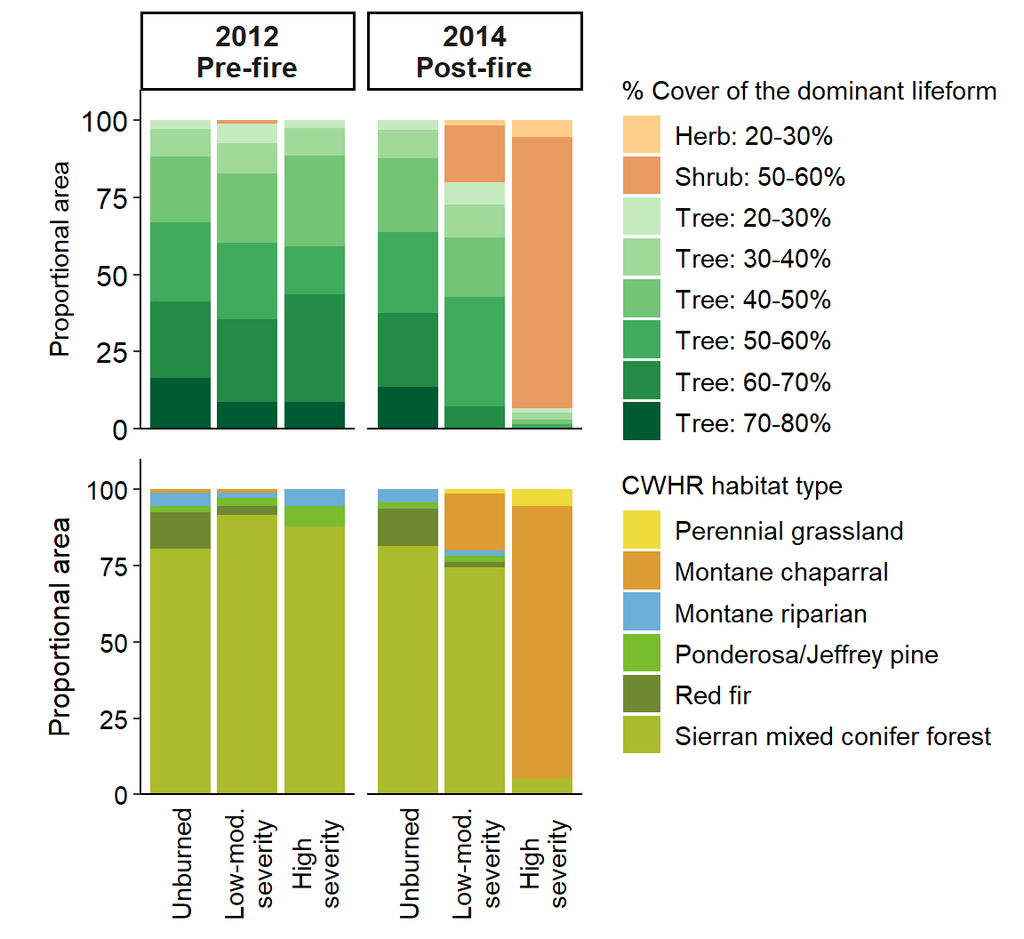

- **Figure 2**

### Comparison of site blocks

- **Block 1:** Devil’s Peak
  - GRNCAR, GRNKAN, GRNWOO, HICOWS, MIXDP2, MIXMID, MIXRAV HISQUE, HIWALK
- **Block 2:** Belt
  - GRNHOU, GRNMAS, GRNTUR, MIXBUS, MIXMIX, MIXMOR, HICORN, HIDODD, HITEDD
- **Block 3:** High Meadows
  - GRNDAM, GRNQUA, GRNSNO, MIXBUT, MIXRIV, MIXWAT, HIBADR, HICAMP, HISHRU

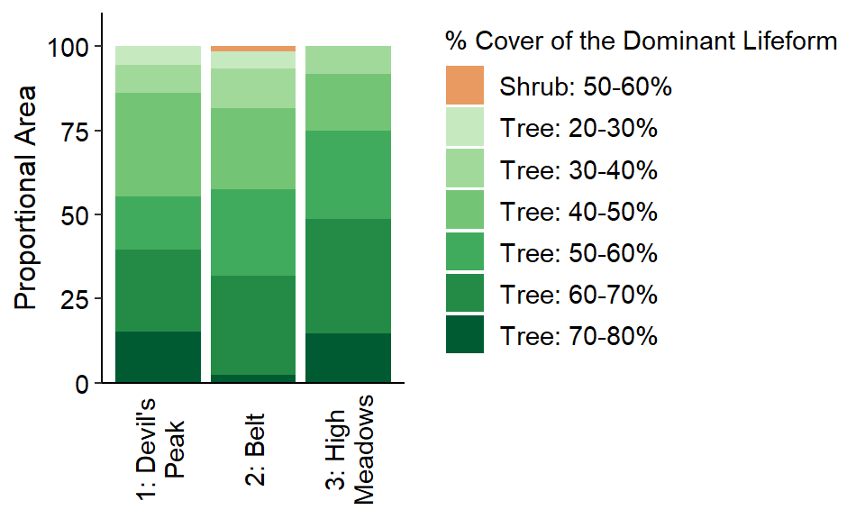

```
##       data    n statistic df        p         method    effsize  method magnitude
## 1 EVC_2014 1830  106.2035  2 8.67e-24 Kruskal-Wallis 0.05703532 eta2[H]     small
```

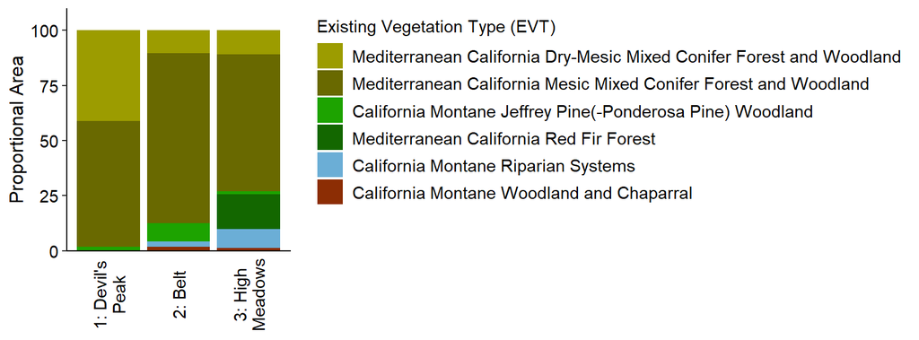

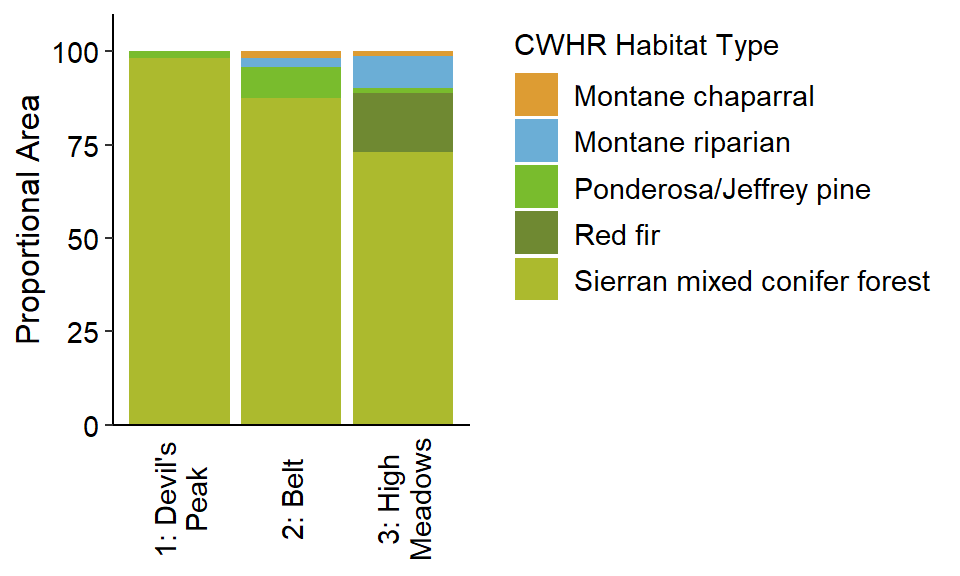